# pokemonAnalysisForFun

J

2024-12-27

12/31 = What to improve on: Making things look pretty, need to review notes more

Just for fun analysis of Pokemon :)

```r
pacman::p_load(
  rio,          # File import
  here,         # File locator
  skimr,        # get overview of data
  tidyverse,    # data management + ggplot2 graphics,
  gtsummary,    # summary statistics and tests
  rstatix,      # statistics
  corrr,        # correlation analayis for numeric variables
  janitor,      # adding totals and percents to tables
  flextable     # converting tables to HTML
)
```

Import data

```r
pokemon <- import("Pokemon.csv")
```

Exploratory Data Analysis

preview of the data

```r
skim(pokemon)
```

Data summary

| Name | pokemon |
| --- | --- |
| Number of rows | 800 |
| Number of columns | 13 |
| _______________________ |  |
| Column type frequency: |  |
| character | 3 |
| logical | 1 |
| numeric | 9 |
| ________________________ |  |
| Group variables | None |

**Variable type: character**

| skim_variable | n_missing | complete_rate | min | max | empty | n_unique | whitespace |
| --- | --- | --- | --- | --- | --- | --- | --- |
| Name | 0 | 1 | 3 | 25 | 0 | 800 | 0 |
| Type 1 | 0 | 1 | 3 | 8 | 0 | 18 | 0 |
| Type 2 | 0 | 1 | 0 | 8 | 386 | 19 | 0 |

**Variable type: logical**

| skim_variable | n_missing | complete_rate | mean | count |
| --- | --- | --- | --- | --- |
| Legendary | 0 | 1 | 0.08 | FAL: 735, TRU: 65 |

**Variable type: numeric**

| skim_variable | n_missing | complete_rate | mean | sd | p0 | p25 | p50 | p75 | p100 | hist |
| --- | --- | --- | --- | --- | --- | --- | --- | --- | --- | --- |
| # | 0 | 1 | 362.81 | 208.34 | 1 | 184.75 | 364.5 | 539.25 | 721 | ▇▇▇▇▇ |
| Total | 0 | 1 | 435.10 | 119.96 | 180 | 330.00 | 450.0 | 515.00 | 780 | ▃▆▇▂▁ |
| HP | 0 | 1 | 69.26 | 25.53 | 1 | 50.00 | 65.0 | 80.00 | 255 | ▃▇▁▁▁ |
| Attack | 0 | 1 | 79.00 | 32.46 | 5 | 55.00 | 75.0 | 100.00 | 190 | ▂▇▆▂▁ |
| Defense | 0 | 1 | 73.84 | 31.18 | 5 | 50.00 | 70.0 | 90.00 | 230 | ▃▇▂▁▁ |
| Sp. Atk | 0 | 1 | 72.82 | 32.72 | 10 | 49.75 | 65.0 | 95.00 | 194 | ▅▇▅▂▁ |
| Sp. Def | 0 | 1 | 71.90 | 27.83 | 20 | 50.00 | 70.0 | 90.00 | 230 | ▇▇▂▁▁ |
| Speed | 0 | 1 | 68.28 | 29.06 | 5 | 45.00 | 65.0 | 90.00 | 180 | ▃▇▆▁▁ |
| Generation | 0 | 1 | 3.32 | 1.66 | 1 | 2.00 | 3.0 | 5.00 | 6 | ▇▅▃▅▂ |

taking a look at the structure/type

```r
str(pokemon)
```

```
## 'data.frame':    800 obs. of  13 variables:
##  $ #         : int  1 2 3 3 4 5 6 6 6 7 ...
##  $ Name      : chr  "Bulbasaur" "Ivysaur" "Venusaur" "VenusaurMega Venusaur" ...
##  $ Type 1    : chr  "Grass" "Grass" "Grass" "Grass" ...
##  $ Type 2    : chr  "Poison" "Poison" "Poison" "Poison" ...
##  $ Total     : int  318 405 525 625 309 405 534 634 634 314 ...
##  $ HP        : int  45 60 80 80 39 58 78 78 78 44 ...
##  $ Attack    : int  49 62 82 100 52 64 84 130 104 48 ...
##  $ Defense   : int  49 63 83 123 43 58 78 111 78 65 ...
##  $ Sp. Atk   : int  65 80 100 122 60 80 109 130 159 50 ...
##  $ Sp. Def   : int  65 80 100 120 50 65 85 85 115 64 ...
##  $ Speed     : int  45 60 80 80 65 80 100 100 100 43 ...
##  $ Generation: int  1 1 1 1 1 1 1 1 1 1 ...
##  $ Legendary : logi  FALSE FALSE FALSE FALSE FALSE FALSE ...
```

Cleaning Up Names (making it into lower case and switching space for underscore)

```r
pokemon <- pokemon %>% janitor::clean_names()

str(pokemon)
```

```
## 'data.frame':    800 obs. of  13 variables:
##  $ number    : int  1 2 3 3 4 5 6 6 6 7 ...
##  $ name      : chr  "Bulbasaur" "Ivysaur" "Venusaur" "VenusaurMega Venusaur" ...
##  $ type_1    : chr  "Grass" "Grass" "Grass" "Grass" ...
##  $ type_2    : chr  "Poison" "Poison" "Poison" "Poison" ...
##  $ total     : int  318 405 525 625 309 405 534 634 634 314 ...
##  $ hp        : int  45 60 80 80 39 58 78 78 78 44 ...
##  $ attack    : int  49 62 82 100 52 64 84 130 104 48 ...
##  $ defense   : int  49 63 83 123 43 58 78 111 78 65 ...
##  $ sp_atk    : int  65 80 100 122 60 80 109 130 159 50 ...
##  $ sp_def    : int  65 80 100 120 50 65 85 85 115 64 ...
##  $ speed     : int  45 60 80 80 65 80 100 100 100 43 ...
##  $ generation: int  1 1 1 1 1 1 1 1 1 1 ...
##  $ legendary : logi  FALSE FALSE FALSE FALSE FALSE FALSE ...
```

~Question how many pokemon have only 1 Type vs 2 Types?

~Question why are there 19 unique pokemon in Type 2?

```r
unique(pokemon$type_2)
```

```
##  [1] "Poison"   ""         "Flying"   "Dragon"   "Ground"   "Fairy"
##  [7] "Grass"    "Fighting" "Psychic"  "Steel"    "Ice"      "Rock"
## [13] "Dark"     "Water"    "Electric" "Fire"     "Ghost"    "Bug"
## [19] "Normal"
```

“” is considered a type

Let’s replace all “” in Type 2 with NAs

```r
pokemon$type_2 <- na_if(pokemon$type_2, "")

skim(pokemon)
```

Data summary

| Name | pokemon |
| --- | --- |
| Number of rows | 800 |
| Number of columns | 13 |
| _______________________ |  |
| Column type frequency: |  |
| character | 3 |
| logical | 1 |
| numeric | 9 |
| ________________________ |  |
| Group variables | None |

**Variable type: character**

| skim_variable | n_missing | complete_rate | min | max | empty | n_unique | whitespace |
| --- | --- | --- | --- | --- | --- | --- | --- |
| name | 0 | 1.00 | 3 | 25 | 0 | 800 | 0 |
| type_1 | 0 | 1.00 | 3 | 8 | 0 | 18 | 0 |
| type_2 | 386 | 0.52 | 3 | 8 | 0 | 18 | 0 |

**Variable type: logical**

| skim_variable | n_missing | complete_rate | mean | count |
| --- | --- | --- | --- | --- |
| legendary | 0 | 1 | 0.08 | FAL: 735, TRU: 65 |

**Variable type: numeric**

| skim_variable | n_missing | complete_rate | mean | sd | p0 | p25 | p50 | p75 | p100 | hist |
| --- | --- | --- | --- | --- | --- | --- | --- | --- | --- | --- |
| number | 0 | 1 | 362.81 | 208.34 | 1 | 184.75 | 364.5 | 539.25 | 721 | ▇▇▇▇▇ |
| total | 0 | 1 | 435.10 | 119.96 | 180 | 330.00 | 450.0 | 515.00 | 780 | ▃▆▇▂▁ |
| hp | 0 | 1 | 69.26 | 25.53 | 1 | 50.00 | 65.0 | 80.00 | 255 | ▃▇▁▁▁ |
| attack | 0 | 1 | 79.00 | 32.46 | 5 | 55.00 | 75.0 | 100.00 | 190 | ▂▇▆▂▁ |
| defense | 0 | 1 | 73.84 | 31.18 | 5 | 50.00 | 70.0 | 90.00 | 230 | ▃▇▂▁▁ |
| sp_atk | 0 | 1 | 72.82 | 32.72 | 10 | 49.75 | 65.0 | 95.00 | 194 | ▅▇▅▂▁ |
| sp_def | 0 | 1 | 71.90 | 27.83 | 20 | 50.00 | 70.0 | 90.00 | 230 | ▇▇▂▁▁ |
| speed | 0 | 1 | 68.28 | 29.06 | 5 | 45.00 | 65.0 | 90.00 | 180 | ▃▇▆▁▁ |
| generation | 0 | 1 | 3.32 | 1.66 | 1 | 2.00 | 3.0 | 5.00 | 6 | ▇▅▃▅▂ |

This kept type_2 as a character type and replaced all the “” with NAs

What is the most common Type 1 and Type 2 groupings?

```r
pokemon %>% group_by(type_1, type_2) %>%
  tally(sort=T) %>%
  ungroup()
```

```
## # A tibble: 154 × 3
##    type_1   type_2     n
##    <chr>    <chr>  <int>
##  1 Normal   <NA>      61
##  2 Water    <NA>      59
##  3 Psychic  <NA>      38
##  4 Grass    <NA>      33
##  5 Fire     <NA>      28
##  6 Electric <NA>      27
##  7 Normal   Flying    24
##  8 Fighting <NA>      20
##  9 Bug      <NA>      17
## 10 Fairy    <NA>      15
## # ℹ 144 more rows
```

How many pokemon are there (including Megas and Forms)?

```r
pokemon %>% group_by(generation) %>%
  tally(sort=T) %>%
  ungroup()
```

```
## # A tibble: 6 × 2
##   generation     n
##        <int> <int>
## 1          1   166
## 2          5   165
## 3          3   160
## 4          4   121
## 5          2   106
## 6          6    82
```

Making a pivot table with stats all in one column, with the exception of total

```r
poke_pivot_long <- pokemon %>% pivot_longer(
  cols     = c('hp':'speed'),
  names_to = 'stats',
  values_to= 'y'
)
```

Plotting these values

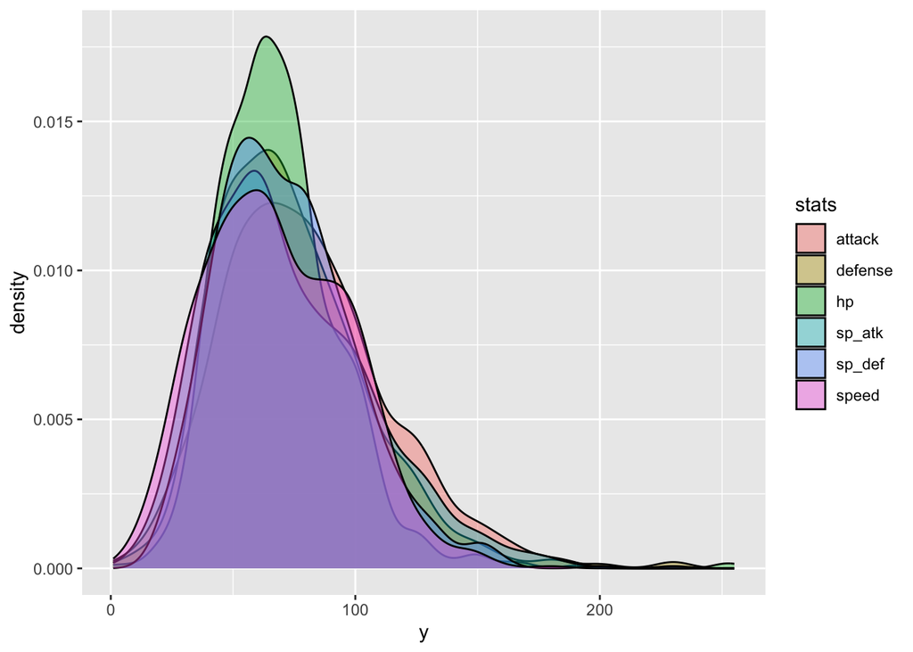

```r
ggplot(data=poke_pivot_long) +
    geom_density(aes(x=y, group=stats, fill=stats), alpha=0.4)
```

Let’s try but with boxplots now

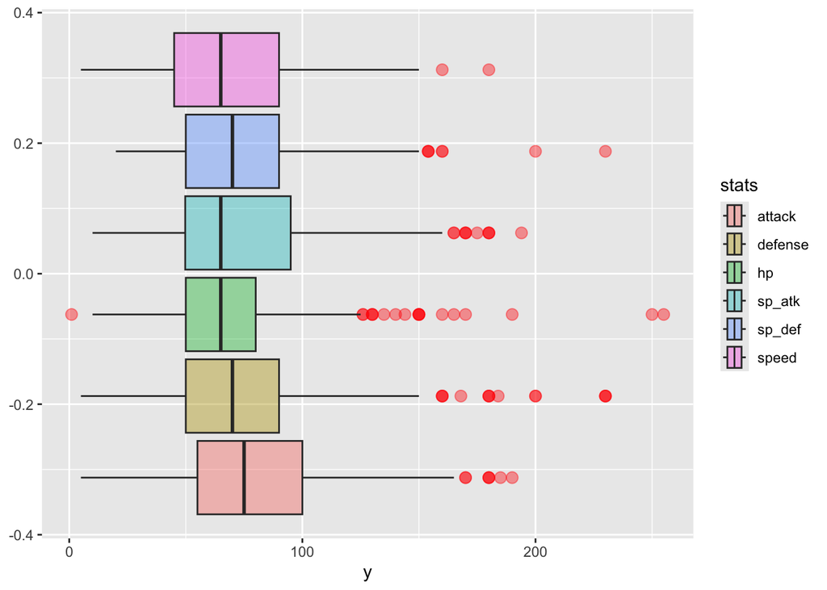

```r
ggplot(data=poke_pivot_long) +
    geom_boxplot(aes(x=y, group=stats, fill=stats),
                 alpha=0.4,
                 outlier.colour="red",
                 outlier.fill="red",
                 outlier.size=3)
```

Reordering boxplots to match it with legend

```r
poke_pivot_long$stats <- factor(poke_pivot_long$stats,
                                 levels = c("speed", "sp_def", "sp_atk", "hp", "defense", "attack"))
```

played around with the parameters in aes

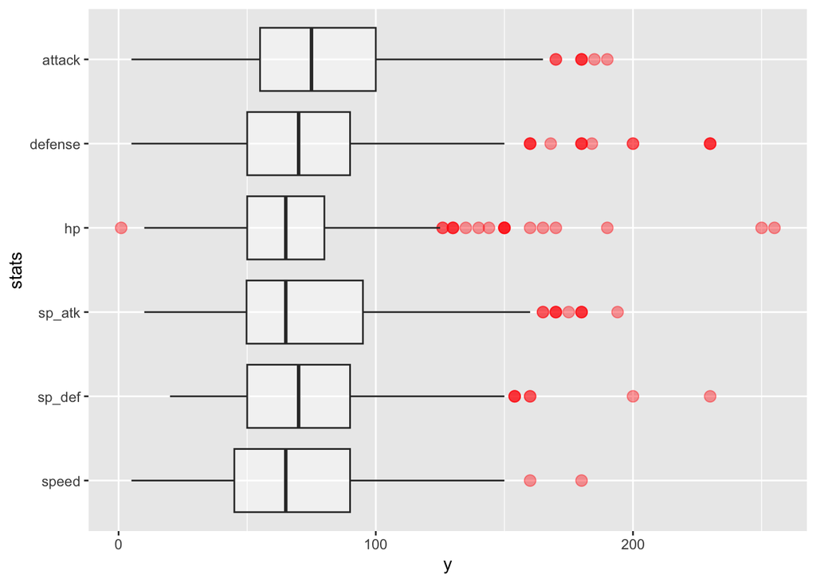

```r
ggplot(data=poke_pivot_long) +
    geom_boxplot(aes(x=y, y=stats),
                 alpha=0.4,
                 outlier.colour="red",
                 outlier.fill="red",
                 outlier.size=3)
```

ok now attack is on top.. but they legend is out of order, so maybe I have to move the legend instead

Let’s see how well pokemon stats correlate with each other

```r
correlation_stats <- pokemon %>%
  select(hp, attack, defense, sp_atk, sp_def, speed) %>%
  correlate()
```

```
## Correlation computed with
## • Method: 'pearson'
## • Missing treated using: 'pairwise.complete.obs'
```

```r
correlation_stats
```

```
## # A tibble: 6 × 7
##   term        hp attack defense sp_atk sp_def   speed
##   <chr>    <dbl>  <dbl>   <dbl>  <dbl>  <dbl>   <dbl>
## 1 hp      NA      0.422  0.240   0.362  0.379  0.176
## 2 attack   0.422 NA      0.439   0.396  0.264  0.381
## 3 defense  0.240  0.439 NA       0.224  0.511  0.0152
## 4 sp_atk   0.362  0.396  0.224  NA      0.506  0.473
## 5 sp_def   0.379  0.264  0.511   0.506 NA      0.259
## 6 speed    0.176  0.381  0.0152  0.473  0.259 NA
```

plotting correlation table

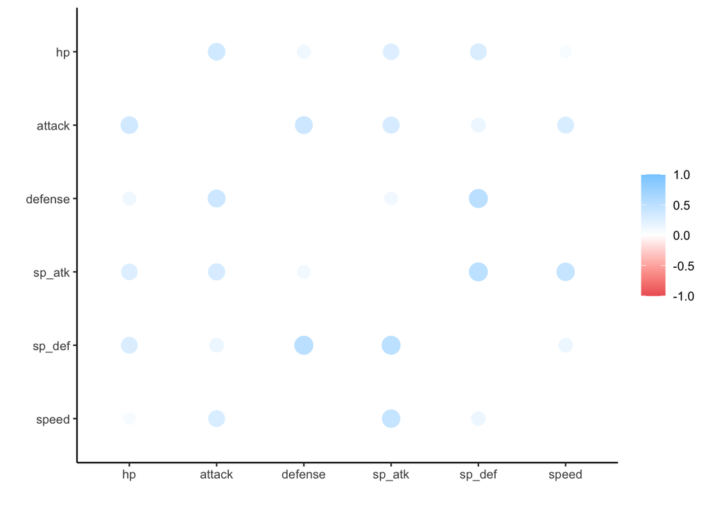

```r
rplot(correlation_stats)
```

single variable analysis

what is the most common pokemon type 1?

```r
pokemon %>%
  group_by(type_1) %>%
  summarise(count = n()) %>%
  arrange(desc(count))
```

```
## # A tibble: 18 × 2
##    type_1   count
##    <chr>    <int>
##  1 Water      112
##  2 Normal      98
##  3 Grass       70
##  4 Bug         69
##  5 Psychic     57
##  6 Fire        52
##  7 Electric    44
##  8 Rock        44
##  9 Dragon      32
## 10 Ghost       32
## 11 Ground      32
## 12 Dark        31
## 13 Poison      28
## 14 Fighting    27
## 15 Steel       27
## 16 Ice         24
## 17 Fairy       17
## 18 Flying       4
```

what is the most common pokemon type 2?

```r
pokemon %>%
  group_by(type_2) %>%
  summarise(count = n()) %>%
  top_n(n=10,wt = count) %>%
  arrange(desc(count)) %>%
  as.data.frame(na.rm=TRUE)
```

```
##      type_2 count
## 1      <NA>   386
## 2    Flying    97
## 3    Ground    35
## 4    Poison    34
## 5   Psychic    33
## 6  Fighting    26
## 7     Grass    25
## 8     Fairy    23
## 9     Steel    22
## 10     Dark    20
```

difference total legendary vs non-legendary?

```r
pokemon %>% group_by(legendary) %>%
    summarise(count = n(),
              hp = mean(hp),
              attack = mean(attack),
              defense = mean(defense),
              sp_atk = mean(sp_atk),
              sp_def = mean(sp_def),
              speed = mean(speed)
              )
```

```
## # A tibble: 2 × 8
##   legendary count    hp attack defense sp_atk sp_def speed
##   <lgl>     <int> <dbl>  <dbl>   <dbl>  <dbl>  <dbl> <dbl>
## 1 FALSE       735  67.2   75.7    71.6   68.5   68.9  65.5
## 2 TRUE         65  92.7  117.     99.7  122.   106.  100.
```

Pretty telling that legendary pokemon are much stronger